# Marker panel reduction

Deep immune cell phenotyping predicts influenza vaccine immunogenicity in HCT recipients

July 21, 2026

# 1 What this notebook does

Mass cytometry is not widely available in clinical laboratories, so translation would need a smaller panel that a common spectral flow cytometer can run. This notebook asks how few markers can carry the predictive signal, and produces **Figure 7**.

The test is deliberately conservative. Within each cross-validation fold, markers are ranked by how much they separate the meta-clusters (between-meta-cluster variance). At each panel size (from all 30 markers down to 6), cells are reassigned to their nearest full-panel cluster center using only the retained markers – the cluster centers themselves are not recomputed. This measures how well a smaller panel approximates the full-panel clustering; a real prospective panel would require building the atlas from scratch on the reduced markers.

Figure 7 has three panels:

- **A** – cluster preservation (the fraction of cells that keep their meta-cluster) versus panel size.
- **B** – held-out prediction error (RMSE of the full model) versus panel size, against the titers-only baseline.
- **C** – the top 15 markers, ranked by their consensus between-cluster variance, colored by marker type.

```r
# Edit these to your local copy of the intermediate data (not distributed; see
# README, Data Availability). The three marker-reduction tables below are
# precomputed per-fold results; nothing here re-runs cell reassignment.
FAST <- "/fast/datasets/flu_cellular_prediction"

MR_DIR   <- file.path(FAST, "post_hoc_5000", "marker_reduction")
PRES_CSV <- file.path(MR_DIR, "E2_preservation.csv")     # cluster preservation per fold/budget
PERF_CSV <- file.path(MR_DIR, "E2_marker_perf.csv")      # held-out MSE per fold/budget/antigen
RANK_CSV <- file.path(MR_DIR, "E2_marker_ranking.csv")   # marker ranking per fold
AGG_PATH <- file.path(FAST, "per_fold_atlas_5000", "aggregated", "E2_aggregated.RData")
```

```r
if (all(file.exists(c(PRES_CSV, PERF_CSV, RANK_CSV)))) {
  pres_dt <- fread(PRES_CSV)
  perf_dt <- fread(PERF_CSV)
  rank_dt <- fread(RANK_CSV)
} else {
  # ---- Heavy compute: for each fold and each panel size, reassign cells to the
  #      nearest full-panel center using only the retained markers, rebuild the
  #      CLR features, and refit the full elastic net. This needs the raw CyTOF
  #      object and the atlas helpers (available from the corresponding author). ----
  stop("Marker-reduction tables not found; see Data Availability.")
}

# Titers-only baseline MSE (M1), for the reference line in Panel B.
load(AGG_PATH)             # provides overall_mse
m1_overall <- overall_mse[["M1_en"]]
BUDGETS <- c(30, 25, 20, 15, 12, 10, 8, 6)
```

# 2 Figure 7

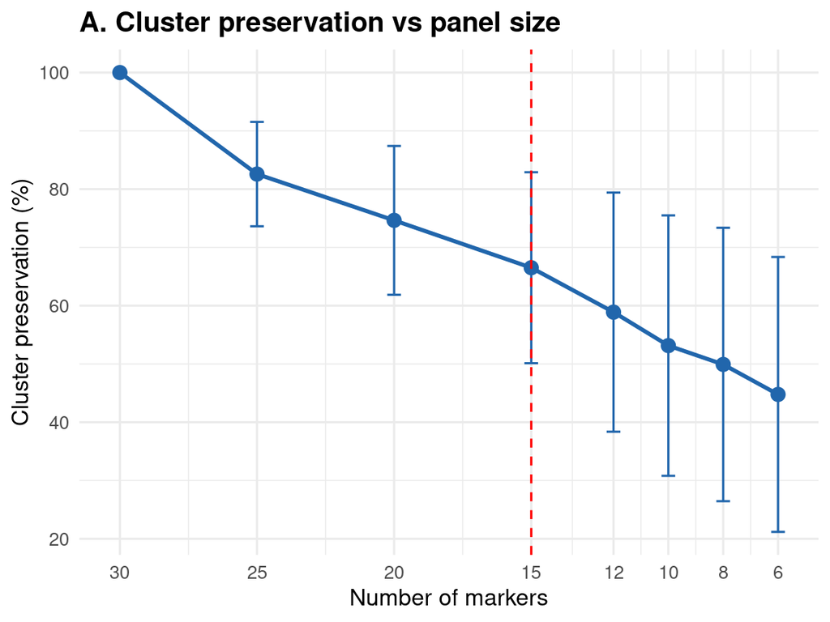

```r
# --- Panel A: cluster preservation vs panel size (mean +/- SD across folds) ---
pres_agg <- pres_dt[, .(mean_match = mean(meta_match), sd_match = sd(meta_match)), by = budget]
p_a <- ggplot(pres_agg, aes(budget, 100 * mean_match)) +
  geom_line(color = "#2166ac", linewidth = 1) +
  geom_point(color = "#2166ac", size = 3) +
  geom_errorbar(aes(ymin = 100 * (mean_match - sd_match), ymax = 100 * (mean_match + sd_match)),
                width = 0.5, color = "#2166ac") +
  geom_vline(xintercept = 15, linetype = "dashed", color = "red") +
  scale_x_reverse(breaks = BUDGETS) +
  labs(x = "Number of markers", y = "Cluster preservation (%)",
       title = "A. Cluster preservation vs panel size") +
  theme_minimal(base_size = 12) +
  theme(plot.title = element_text(face = "bold"))
p_a
```

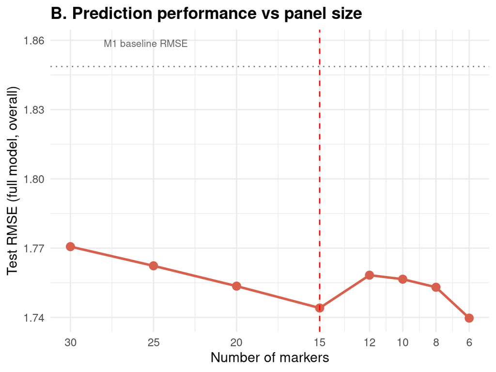

```r
# --- Panel B: held-out RMSE (full model, overall) vs panel size ---
# Per fold/budget, the overall MSE is the mean across the three antigens.
perf_dt[, overall_mse := mean(cluster_test_mse), by = .(fold, budget)]
perf_agg <- unique(perf_dt[, .(fold, budget, overall_mse)])[
  , .(mean_mse = mean(overall_mse)), by = budget]
perf_agg[, rmse := sqrt(mean_mse)]
rmse_baseline <- sqrt(m1_overall)

p_b <- ggplot(perf_agg, aes(budget, rmse)) +
  geom_line(color = "#d6604d", linewidth = 1) +
  geom_point(color = "#d6604d", size = 3) +
  geom_hline(yintercept = rmse_baseline, linetype = "dotted", color = "gray50") +
  geom_vline(xintercept = 15, linetype = "dashed", color = "red") +
  annotate("text", x = 28, y = rmse_baseline + 0.01, label = "M1 baseline RMSE",
           color = "gray40", size = 3, hjust = 0) +
  scale_x_reverse(breaks = BUDGETS) +
  labs(x = "Number of markers", y = "Test RMSE (full model, overall)",
       title = "B. Prediction performance vs panel size") +
  theme_minimal(base_size = 12) +
  theme(plot.title = element_text(face = "bold"))
p_b
```

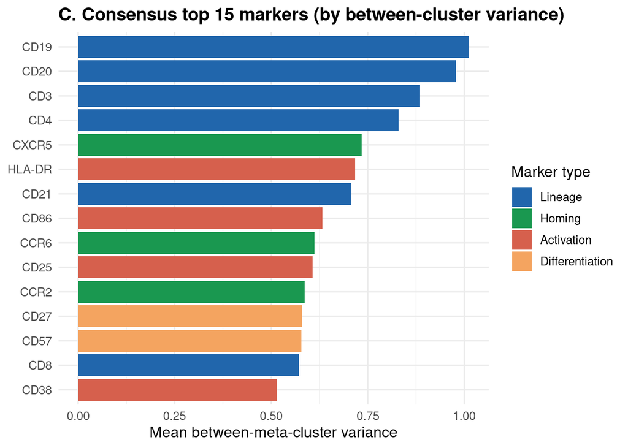

```r
# --- Panel C: top 15 consensus markers, colored by marker type ---
consensus <- rank_dt[, .(mean_var = mean(between_meta_var)), by = marker][order(-mean_var)]
top15 <- consensus[1:15]

# Marker-type grouping for the 15-marker panel (lineage / homing / activation /
# differentiation), matching the manuscript's spectral-flow-compatible panel.
marker_type <- c(
  CD19 = "Lineage", CD20 = "Lineage", CD3 = "Lineage", CD4 = "Lineage",
  CD8 = "Lineage", CD21 = "Lineage",
  CXCR5 = "Homing", CCR6 = "Homing", CCR2 = "Homing",
  `HLA-DR` = "Activation", CD86 = "Activation", CD25 = "Activation", CD38 = "Activation",
  CD27 = "Differentiation", CD57 = "Differentiation")
top15[, type := factor(marker_type[marker],
                       levels = c("Lineage", "Homing", "Activation", "Differentiation"))]
type_colors <- c(Lineage = "#2166ac", Homing = "#1a9850",
                 Activation = "#d6604d", Differentiation = "#f4a460")

p_c <- ggplot(top15, aes(reorder(marker, mean_var), mean_var, fill = type)) +
  geom_col() +
  coord_flip() +
  scale_fill_manual(values = type_colors, name = "Marker type") +
  labs(x = NULL, y = "Mean between-meta-cluster variance",
       title = "C. Consensus top 15 markers (by between-cluster variance)") +
  theme_minimal(base_size = 12) +
  theme(plot.title = element_text(face = "bold"), legend.position = "right")
p_c
```

```r
cat("Cluster preservation at 30 / 15 / 12 markers (per-fold mean):\n")
```

```
## Cluster preservation at 30 / 15 / 12 markers (per-fold mean):
```

```r
print(pres_agg[budget %in% c(30, 15, 12), .(budget, preservation_pct = round(100 * mean_match, 1))])
```

```
##    budget preservation_pct
##     <int>            <num>
## 1:     30            100.0
## 2:     15             66.5
## 3:     12             58.9
```

```r
cat("\nTest RMSE at 30 vs 15 markers:\n")
```

```
##
## Test RMSE at 30 vs 15 markers:
```

```r
print(perf_agg[budget %in% c(30, 15), .(budget, rmse = round(rmse, 3))])
```

```
##    budget  rmse
##     <int> <num>
## 1:     30 1.771
## 2:     15 1.744
```